# 学校付加価値の推定シミュレーション

Soichiro Sugita

# パネルデータ(500校×4年)でシミュレーション

## シミュレーション用データ

```r
library(dplyr)
```

```r
library(ggplot2)
library(fixest)

set.seed(456)

# パラメータ設定
n_schools <- 500
n_years <- 4
noise_sd <- 35       # ノイズ大きめ
signal_sd <- 2      # 真のμの分散

# 真の学校効果
mu_school <- rnorm(n_schools, mean = 0, sd = signal_sd)

# 生徒数（対数正規分布） → 小規模＆左偏、最低5人に制限
students_per_school_year <- matrix(rlnorm(n_schools * n_years, meanlog = 3.2, sdlog = 0.6),
                                   nrow = n_schools, ncol = n_years)
students_per_school_year <- round(pmax(students_per_school_year, 5))

# データ生成
sim_list <- list()
student_id <- 1

for (j in 1:n_schools) {
  for (t in 1:n_years) {
    n_students <- students_per_school_year[j, t]
    SES <- rnorm(n_students)
    score_t_1 <- rnorm(n_students, 58, 14)
    epsilon <- rnorm(n_students, 0, noise_sd)
    score <- 0.6 * score_t_1 + 3.0 * SES + mu_school[j] + epsilon
    score <- pmin(pmax(score, 0), 100)

    sim_list[[length(sim_list) + 1]] <- data.frame(
      student_id = student_id:(student_id + n_students - 1),
      school_id = as.factor(j),
      year = as.factor(t),
      SES = SES,
      score_t_1 = score_t_1,
      score_t = score,
      true_mu = mu_school[j]
    )

    student_id <- student_id + n_students
  }
}
panel_data <- bind_rows(sim_list)

# 固定効果推定（学校＋年固定効果）
fe_model <- feols(score_t ~ score_t_1 + SES | school_id + year, data = panel_data)
fe_effects <- as.data.frame(fixef(fe_model)$school_id)
fe_effects$school_id <- rownames(fe_effects)
colnames(fe_effects)[1] <- "fe_estimate"

# 学校ごとの生徒数
school_sizes <- panel_data %>%
  group_by(school_id) %>%
  summarise(n = n(), .groups = "drop")

# 残差分散の推定
panel_data$resid <- resid(fe_model)
sigma_sq <- var(panel_data$resid)

# 標準誤差の逆畳み込みバージョン（添付ファイルに基づく）
merged <- left_join(fe_effects, school_sizes, by = "school_id")
mean_fe <- mean(merged$fe_estimate)

# 各学校の分散貢献分と推定誤差とみなす誤差
merged <- merged %>%
  mutate(sq_diff = (fe_estimate - mean_fe)^2,
         se2 = sigma_sq / n)

true_var <- mean(merged$sq_diff - merged$se2)  # 逆畳み込み：観測分散 - 標準誤差分散
true_var <- max(true_var, 0.0001)

# Shrinkage + EB推定値
merged$shrinkage_weight <- true_var / (true_var + sigma_sq / merged$n)
merged$eb_estimate <- mean_fe + merged$shrinkage_weight * (merged$fe_estimate - mean_fe)

# 真のμと結合
true_mu_df <- data.frame(school_id = as.factor(1:n_schools), true_mu = mu_school)
result <- left_join(merged, true_mu_df, by = "school_id")

# MSEの計算
mse_fe <- mean((result$fe_estimate - result$true_mu)^2)
mse_eb <- mean((result$eb_estimate - result$true_mu)^2)

# Top 5% ランキングの一致率とFDR
top_n <- ceiling(0.05 * n_schools)
top_true <- order(result$true_mu, decreasing = TRUE)[1:top_n]
top_fe <- order(result$fe_estimate, decreasing = TRUE)[1:top_n]
top_eb <- order(result$eb_estimate, decreasing = TRUE)[1:top_n]

fdr <- function(pred_top, true_top) {
  1 - mean(pred_top %in% true_top)
}
acc <- function(pred_top, true_top) {
  mean(pred_top %in% true_top)
}

fdr_fe <- fdr(top_fe, top_true)
fdr_eb <- fdr(top_eb, top_true)
acc_fe <- acc(top_fe, top_true)
acc_eb <- acc(top_eb, top_true)

# 出力
cat("✅ MSE（固定効果）:", round(mse_fe, 3), "\n")
```

```
## ✅ MSE（固定効果）: 108.718
```

```r
cat("✅ MSE（経験ベイズ）:", round(mse_eb, 3), "\n\n")
```

```
## ✅ MSE（経験ベイズ）: 103.296
```

```r
cat("🔍 Top 5% 一致率（FE）:", round(acc_fe, 3), "\n")
```

```
## 🔍 Top 5% 一致率（FE）: 0.24
```

```r
cat("🔍 Top 5% 一致率（EB）:", round(acc_eb, 3), "\n")
```

```
## 🔍 Top 5% 一致率（EB）: 0.24
```

```r
cat("🚨 FDR（FE）:", round(fdr_fe, 3), "\n")
```

```
## 🚨 FDR（FE）: 0.76
```

```r
cat("🚨 FDR（EB）:", round(fdr_eb, 3), "\n")
```

```
## 🚨 FDR（EB）: 0.76
```

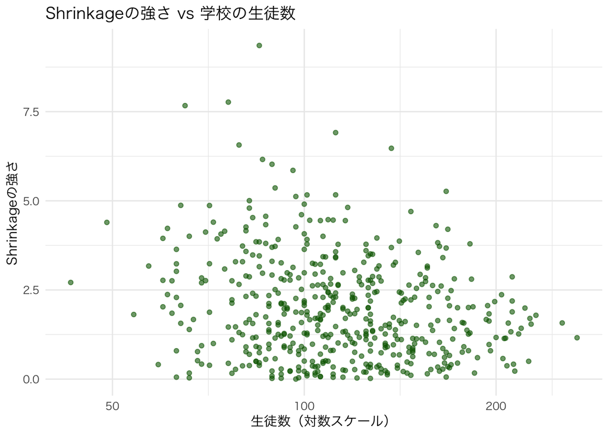

```r
# 真の値 vs 推定値（FE & EB）
library(ggplot2)

# # データフレーム result を前提とします
# p1 <- ggplot(result, aes(x = true_mu)) +
#   geom_point(aes(y = fe_estimate, color = "固定効果"), alpha = 0.5) +
#   geom_point(aes(y = eb_estimate, color = "経験ベイズ"), alpha = 0.5) +
#   geom_abline(slope = 1, intercept = 0, linetype = "dashed") +
#   labs(title = "真の効果 vs 推定値（FE vs EB）",
#        x = "真の学校効果",
#        y = "推定値",
#        color = "推定法") +
#   scale_color_manual(values = c("固定効果" = "red", "経験ベイズ" = "blue")) +
#   theme_minimal(base_family = "HiraKakuProN-W3")

# Shrinkageの強さ vs 生徒数
result$shrinkage_strength <- abs(result$fe_estimate - result$eb_estimate)

p2 <- ggplot(result, aes(x = n, y = shrinkage_strength)) +
  geom_point(alpha = 0.6, color = "darkgreen") +
  scale_x_log10() +
  labs(title = "Shrinkageの強さ vs 学校の生徒数",
       x = "生徒数（対数スケール）",
       y = "Shrinkageの強さ") +
  theme_minimal(base_family = "HiraKakuProN-W3")

# 推定値のランキング順位比較
result$rank_true <- rank(-result$true_mu)
result$rank_fe <- rank(-result$fe_estimate)
result$rank_eb <- rank(-result$eb_estimate)

p3 <- ggplot(result, aes(x = rank_true)) +
  geom_point(aes(y = rank_fe, color = "固定効果"), alpha = 0.5) +
  geom_point(aes(y = rank_eb, color = "経験ベイズ"), alpha = 0.5) +
  geom_abline(slope = 1, intercept = 0, linetype = "dashed") +
  labs(title = "真の順位 vs 推定順位（FE & EB）",
       x = "真の学校順位",
       y = "推定順位",
       color = "推定法") +
  scale_color_manual(values = c("固定効果" = "red", "経験ベイズ" = "blue")) +
  theme_minimal(base_family = "HiraKakuProN-W3")

# 表示
# print(p1)
print(p2)
```

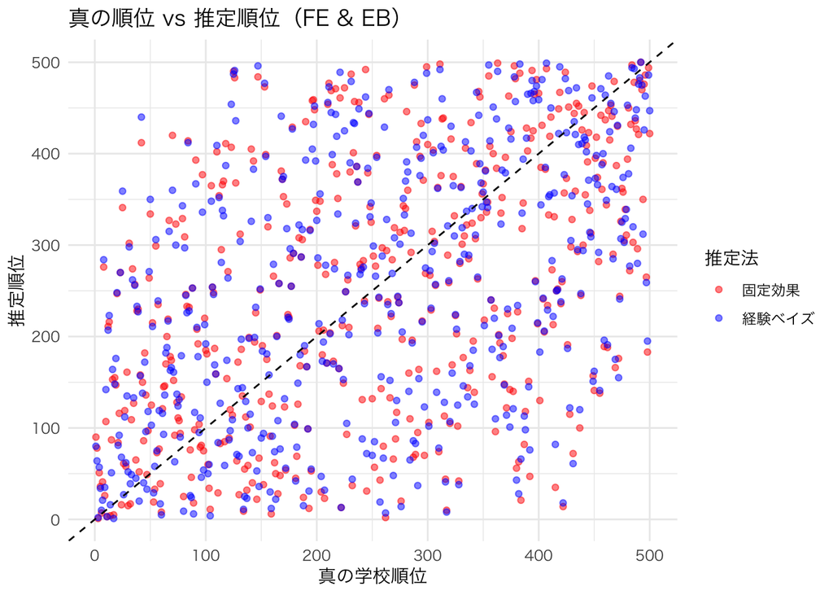

```r
print(p3)
```

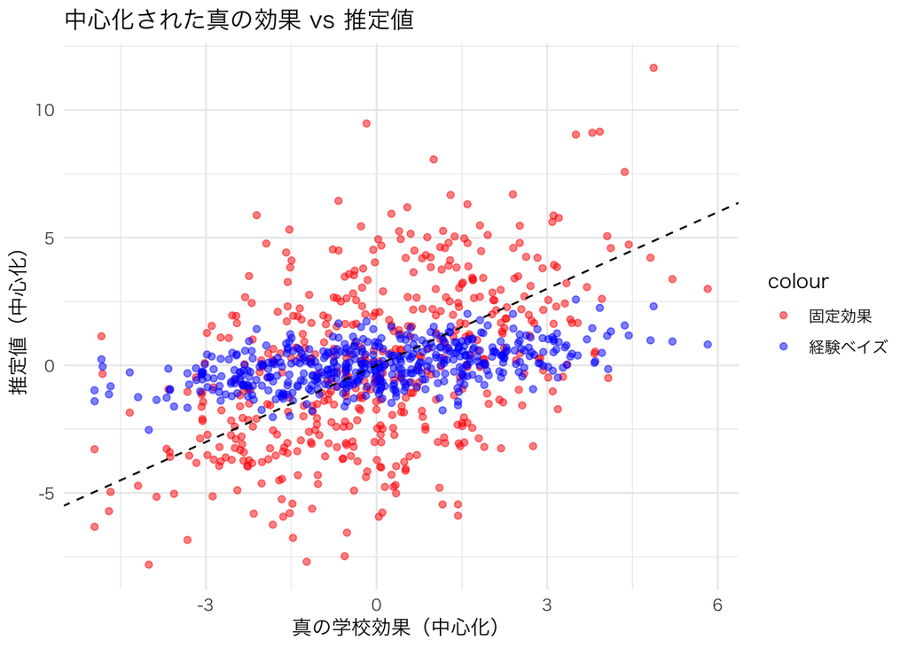

```r
# 中心化------------------
result$true_centered <- result$true_mu - mean(result$true_mu)
result$fe_centered <- result$fe_estimate - mean(result$fe_estimate)
result$eb_centered <- result$eb_estimate - mean(result$eb_estimate)

# プロット（中心化バージョン）
ggplot(result, aes(x = true_centered)) +
  geom_point(aes(y = fe_centered, color = "固定効果"), alpha = 0.5) +
  geom_point(aes(y = eb_centered, color = "経験ベイズ"), alpha = 0.5) +
  geom_abline(slope = 1, intercept = 0, linetype = "dashed") +
  labs(title = "中心化された真の効果 vs 推定値", x = "真の学校効果（中心化）", y = "推定値（中心化）") +
  scale_color_manual(values = c("固定効果" = "red", "経験ベイズ" = "blue")) +
  theme_minimal(base_family = "HiraKakuProN-W3")
```

# シミュレーション概要

本シミュレーションは以下の条件で学校付加価値（Value-Added）を推定し、固定効果（FE）と経験ベイズ（EB）の性能を比較する。

- 📉 生徒数が小さい（平均 20〜30 人）
- 🎲 ノイズが大きい（SD = 35）
- 🌀 真の学校効果のばらつきが小さい（SD = 2）

# 数式による説明

## Step 1: 観測データ生成

$$Y_{ijt} = \alpha \cdot Y_{ij(t-1)} + \beta \cdot \text{SES}_{ijt} +
\mu_j + \varepsilon_{ijt}, \quad \varepsilon_{ijt} \sim N(0, \sigma^2)$$

- ここで、$Y_{ij(t-1)}$ は生徒 $i$ が年 $t-1$ に取得したテストスコア（ラグ変数）を表す。
- 本モデルでは、生徒の現在のスコア $Y_{ijt}$ は、過年度のスコア・SES・学校効果・ノイズの影響を受けて決定される。

## Step 2: 固定効果による推定

$$\hat{\theta}_j = \frac{1}{n_j} \sum_{i \in j} \left(Y_{ijt} -
\hat{\alpha} \cdot Y_{ij(t-1)} - \hat{\beta} \cdot
\text{SES}_{ijt}\right)$$

## Step 3: 経験ベイズ（Shrinkage）推定と事後分布の更新

学校付加価値 $\mu_j$ は以下のような混合分布（Mixing distribution）から事前分布として仮定される：

$$\mu_j \sim G = N(\bar{\mu}, \tau^2)$$

ここで、

- $\bar{\mu}$：学校効果の平均（全体平均）
- $\tau^2$：学校効果の分散（between-school variance）
- $\sigma^2$：誤差分散（within-school variance）

### ハイパーパラメータの推定（経験ベイズ）

経験ベイズでは、$\bar{\mu}$ および $\tau^2$ は観測データから以下のように推定される。 特に、$s_j$ を $\hat{\theta}_j$ の標準誤差とした場合：

$$\hat{\mu}_\theta = \frac{1}{J} \sum_{j=1}^J \hat{\theta}_j,$$

$$\hat{\tau}^2 = \frac{1}{J} \sum_{j=1}^J \left[(\hat{\theta}_j -
\hat{\mu}_\theta)^2 - s_j^2 \right]$$

このように逆畳み込み（deconvolution）により、推定値のばらつきから標準誤差を差し引いて真の分散 $\tau^2$ を求める。

これにより、観測された $\hat{\theta}_j$ に基づく事後分布の平均は、以下のような重み付け平均になる：

$$\tilde{\theta}_j = w_j \cdot \hat{\theta}_j + (1 - w_j) \cdot \bar{\mu}$$

Shrinkage weight $w_j$ は以下の式で表される：

$$w_j = \frac{\tau^2}{\tau^2 + \sigma^2 / n_j}$$

- $n_j$：学校 $j$ の観測生徒数
- $w_j \in [0, 1]$：Shrinkageの強さを表し、小規模な学校ほど $w_j$ が小さく、強く平均に引き寄せられる。

この更新式は、ベイズの定理に基づく以下の事後平均：

$$\mu_j | \hat{\theta}_j \sim N(\tilde{\theta}_j, \text{Var})$$
の平均値を意味しており、経験的に推定された $\tau^2$ を用いることで経験ベイズ推定が成立する。

# 精度評価結果

[output not shown]

## 順位相関（Spearman）

[output not shown]

## 解釈

# 結論